# Titanic_TrainData_Discussion_One

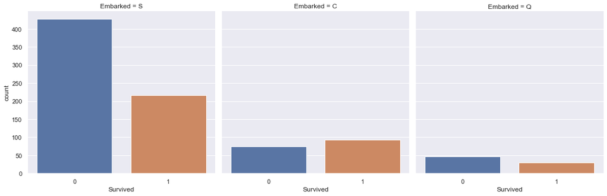

```python
#Curious if a specific embarkation location determined likelihood of survival.
#It seems embarking from Cherbourg gave one the best chances of surviving per embarkation point.

sns.factorplot(x='Survived', col='Embarked', kind='count', data=df_train)
```

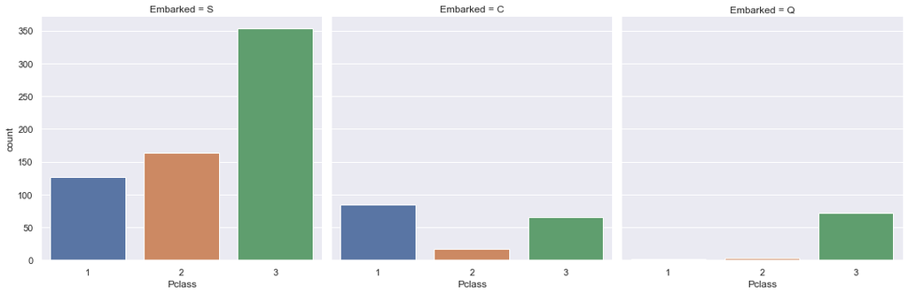

```python
#This begins my own personal EDA outside of that described by the Kaggle discussion
#Curious if the type of location had more of a certain class of passenger, which might help explain
#the above suvivability of those joining from Cherbourg.

sns.factorplot(x='Pclass', col='Embarked', kind='count', data=df_train)
```

```python
#survivability of passengers per class (1,2,3)
print(df_train[df_train.Pclass == 1].Survived.sum()/df_train[df_train.Pclass == 1].Survived.count())
print(df_train[df_train.Pclass == 2].Survived.sum()/df_train[df_train.Pclass == 2].Survived.count())
print(df_train[df_train.Pclass == 3].Survived.sum()/df_train[df_train.Pclass == 3].Survived.count())
```

```
0.6296296296296297
0.47282608695652173
0.24236252545824846
```

The majority of passengers from Cherbourg were those in first clas. With the survivability of first class being more likely to survive than perish, it makes sense why those boarding at Cherbourg (higher proportion of first class) would have survived in greater proportions than those boarding at different locations.

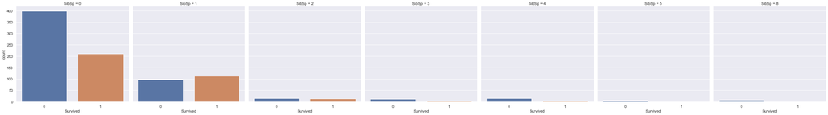

```python
#I'm really curious about the likelihood of those traveling with immediate family members (less than
#half as detailed in the descriptive stats) of surviving

sns.factorplot(x='Survived', col='SibSp', kind='count', data=df_train)
```

```python
#For fun I'm going to create a new variable to evaluate if an individual was traveling with one or
#more immediate family members to evaluate their likelihood of survival.

#double == poses a question, is this entry true? or is it false? If true will return true, if not false
df_train['Family'] = df_train.SibSp != 0
df_train.head(n=10)

#But we don't want trues or falses, we want 0s and 1s, so apply a fxn to change all trues to 1 &
#all falses to 0
df_train['Family'] = df_train.Family.apply(lambda x: int(x))
df_train.head(n=10)
```

|  | PassengerId | Survived | Pclass | Name | Sex | Age | SibSp | Parch | Ticket | Fare | Cabin | Embarked | Family |
| --- | --- | --- | --- | --- | --- | --- | --- | --- | --- | --- | --- | --- | --- |
| 0 | 1 | 0 | 3 | Braund, Mr. Owen Harris | male | 22.0 | 1 | 0 | A/5 21171 | 7.2500 | NaN | S | 1 |
| 1 | 2 | 1 | 1 | Cumings, Mrs. John Bradley (Florence Briggs Th... | female | 38.0 | 1 | 0 | PC 17599 | 71.2833 | C85 | C | 1 |
| 2 | 3 | 1 | 3 | Heikkinen, Miss. Laina | female | 26.0 | 0 | 0 | STON/O2. 3101282 | 7.9250 | NaN | S | 0 |
| 3 | 4 | 1 | 1 | Futrelle, Mrs. Jacques Heath (Lily May Peel) | female | 35.0 | 1 | 0 | 113803 | 53.1000 | C123 | S | 1 |
| 4 | 5 | 0 | 3 | Allen, Mr. William Henry | male | 35.0 | 0 | 0 | 373450 | 8.0500 | NaN | S | 0 |
| 5 | 6 | 0 | 3 | Moran, Mr. James | male | NaN | 0 | 0 | 330877 | 8.4583 | NaN | Q | 0 |
| 6 | 7 | 0 | 1 | McCarthy, Mr. Timothy J | male | 54.0 | 0 | 0 | 17463 | 51.8625 | E46 | S | 0 |
| 7 | 8 | 0 | 3 | Palsson, Master. Gosta Leonard | male | 2.0 | 3 | 1 | 349909 | 21.0750 | NaN | S | 1 |
| 8 | 9 | 1 | 3 | Johnson, Mrs. Oscar W (Elisabeth Vilhelmina Berg) | female | 27.0 | 0 | 2 | 347742 | 11.1333 | NaN | S | 0 |
| 9 | 10 | 1 | 2 | Nasser, Mrs. Nicholas (Adele Achem) | female | 14.0 | 1 | 0 | 237736 | 30.0708 | NaN | C | 1 |

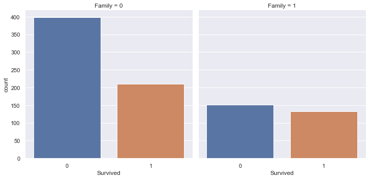

```python
#Plotting survivals of those traveling with family vs not
family_fig = sns.factorplot(x='Survived', col='Family', kind='count', data=df_train)
family_fig.savefig('family_fig.png')
```

```python
#Percentage survival of those traveling with immediate family / those that are not
print(df_train[df_train.Family == 1].Survived.sum()/df_train[df_train.Family == 1].Survived.count())
print(df_train[df_train.Family == 0].Survived.sum()/df_train[df_train.Family == 0].Survived.count())
```

```
0.4664310954063604
0.34539473684210525
```

Interestingly, those that are traveling with family have a slightly better percentage of survival than those who are not. As with the embarkation location, this could potentially be due to the fare class of those with family - it would make sense for those who are wealthy to be able to afford to bring their immediate family members along for the voyage.

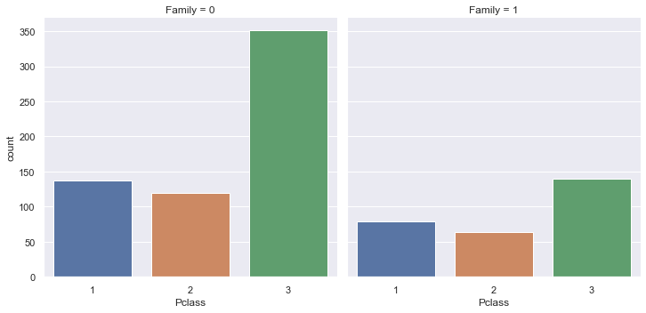

```python
#looking at the breakdown of classes of those traveling without family as compared to those traveling
#with family

titanic_fig = sns.factorplot(x='Pclass', col='Family', kind='count', data=df_train)

titanic_fig.savefig('titanic_fig.png')
```

As expected a majority of third class passengers were traveling alone, but interestingly the proportions of first and second class without family mirror those with family, the same being the case to some extent with third class with the greatest number of passengers traveling with family were in third.